# Safe Passage Brain Responses

```r
eeg_data <- read.csv("Data/csv/all_meas_new.csv") %>%
  mutate_if(is.character, function(x)
    gsub(
      pattern = "'",
      replacement = "",
      x = x
    ))
head(eeg_data)
```

|  | id | cond | f.b | reg | n.clean.ep | can.pow | foof.rsq | foof.int | foof.sl | per.pk.fr | per.pk.amp | per.pow |
| --- | --- | --- | --- | --- | --- | --- | --- | --- | --- | --- | --- | --- |
| 1 | SP00002 | social | theta | Frontal | 57 | 1.1950616 | 0.9934348 | 1.703193 | 1.738912 | NaN | NaN | 0.09233763 |
| 2 | SP00002 | social | theta | Central | 57 | 0.9235244 | 0.9887736 | 1.458197 | 1.690451 | NaN | NaN | 0.18539790 |
| 3 | SP00002 | social | theta | Parietal | 57 | 1.0755219 | 0.9956349 | 1.817033 | 1.987267 | NaN | NaN | 0.10992404 |
| 4 | SP00002 | social | theta | Occipital | 57 | 1.0553618 | 0.9954596 | 1.634226 | 1.676180 | NaN | NaN | 0.05658550 |
| 5 | SP00002 | social | alpha | Frontal | 57 | 0.5269795 | 0.9934348 | 1.703193 | 1.738912 | 9.414832 | 0.554419 | 0.26203373 |
| 6 | SP00002 | social | alpha | Central | 57 | 0.8309347 | 0.9887736 | 1.458197 | 1.690451 | 9.471345 | 1.413226 | 0.63675890 |

# Clinical & Demographic variables

```r
all_vars <- read.csv("Data/csv/SafePassageSummaryScores.csv") %>%
  mutate(ELC = rowSums(.[c(139, 144, 149)])) # Early Learning Composite (ELC) = VisualReception_Raw, ReceptiveLanguage_RawScore, ExpressiveLanguage_RawScore
```

```r
melc <- mean(all_vars$ELC, na.rm = TRUE)
selc <- sd(all_vars$ELC, na.rm = TRUE)
vsm <-
  mean((
    all_vars$RecpetiveLanguage_Tscore + all_vars$ExpressiveLanguage_Tscore
  ) / 2,
  na.rm = TRUE
  )
vss <-
  sd((
    all_vars$RecpetiveLanguage_Tscore + all_vars$ExpressiveLanguage_Tscore
  ) / 2,
  na.rm = TRUE
  )
vrm <- mean(all_vars$VisualReception_Tscore, na.rm = TRUE)
vrs <- sd(all_vars$VisualReception_Tscore, na.rm = TRUE)

all_vars <- all_vars %>%
  mutate(
    ELC.st = 100 + (ELC - melc) * (15 / selc),
    FIQ_ELC = ifelse(is.na(FSIQ), ELC.st, FSIQ),

    VS = 100 + (((RecpetiveLanguage_Tscore + ExpressiveLanguage_Tscore) /
                   2
    ) - vsm) * (15 / vss),
    VR = 100 + (VisualReception_Tscore - vsm) * (15 / vrs),

    VCI_alt = ifelse(is.na(VCI), VS, VCI),
    PRI_alt = ifelse(is.na(PRI), VR, PRI),

    age.group = ifelse(Age_yrs < 6, 1, ifelse(
      Age_yrs < 11 & Age_yrs >= 6, 2, ifelse(Age_yrs >= 11, 3, NA)
    ))
  )
```

```r
cl_demo_vars <- all_vars[!duplicated(all_vars$Subject),] %>%
  select(
    Subject,
    Gender,
    Age_yrs,
    #age.group,
    FIQ_ELC,
    # COLIFE,
    VCI_alt,
    PRI_alt,
    # VisualReception_Tscore,
    # RecpetiveLanguage_Tscore,
    # ExpressiveLanguage_Tscore,
    #OLIFE_Mother,
    # maritalStatus,
    #Employed..0.no.1.yes.,
    #educationYears,
    #BMI...kg.m_.,
    household_income,
    # typeHouse,
    #phone..0.no.1.yes.,
    #water..0.no.1.yes.,
    #toilet..0.no.1.yes.,
    # Risk_TOTAL,
    # Protective_TOTAL,
    #Edinburgh.score,
    #PARITY..life.birth.,
    #CigsPerDayPreg,
    #TotalStdDrinksPreg,
    #Preterm...0.no.1.yes.,
    SDQ_tot,
    CARS_Total_Raw
  ) %>%
  rename(id = Subject) %>%
  mutate(id = gsub(
    pattern = "002-BISH-",
    replacement = "P",
    x = id
  ))
```

# Session info from tracker

```r
tracker <- read.csv("Data/csv/tracker.csv")
tracker <- tracker[!duplicated(tracker$id),] %>%
  select(-c(17:21)) %>%
  mutate_if(is.character, function(x)
    gsub(
      pattern = " ",
      replacement = "",
      x = x
    )) %>%
  select(id, age_ymd, time_capping_m)
```

# ET Data

```r
et_data <- read.csv("Data/csv/et_data.csv") %>%
  mutate(cond = ifelse(event == "FACE_EN.mp4", "social", "non-social")) %>%
  group_by(id, cond) %>%
  summarise_at(.vars = 6:11, mean)
```

# Merge all datasets

```r
eeg_data_m <- eeg_data %>%
  left_join(cl_demo_vars, by = "id") %>%
  left_join(et_data, by = c("id", "cond")) %>%
  left_join(tracker, by = "id")
ds <- filter(eeg_data_m, n.clean.ep > 20 & foof.rsq > 0.95)
```

# Descriptive Statistics

```r
summ.all <- ds %>%
  filter(!if_all(Gender:CARS_Total_Raw, is.na)) %>%
  group_by(id, Gender, Age_yrs, VCI_alt, PRI_alt, FIQ_ELC, CARS_Total_Raw, SDQ_tot, household_income, time_capping_m) %>%
  summarise(et_looking_prop = mean(et_looking_prop, na.rm=TRUE)) %>%
  as.data.frame() %>%
  summarise(N=n(),
            `N fem`=sum(Gender=="Female", na.rm = TRUE),
            `M:F`=round(sum(Gender=="Male", na.rm = TRUE)/sum(Gender=="Female", na.rm = TRUE), 2),
            `Age (SD)`= paste0(round(mean(Age_yrs, na.rm=TRUE), 2),
                                 " (",
                                 round(sd(Age_yrs, na.rm=TRUE), 2),
                                 ", ",
                                 round(max(Age_yrs, na.rm=TRUE)-min(Age_yrs, na.rm=TRUE), 2),
                                 ")"),
            `VCI (SD)`= paste0(round(mean(VCI_alt, na.rm=TRUE), 2),
                                 " (",
                                 round(sd(VCI_alt, na.rm=TRUE), 2),
                                 ", ",
                                 round(max(VCI_alt, na.rm=TRUE)-min(VCI_alt, na.rm=TRUE), 2),
                                 ")"),
            `PRI (SD)`= paste0(round(mean(PRI_alt, na.rm=TRUE), 2),
                                 " (",
                                 round(sd(PRI_alt, na.rm=TRUE), 2),
                                 ", ",
                                 round(max(PRI_alt, na.rm=TRUE)-min(PRI_alt, na.rm=TRUE), 2),
                                 ")"),
            ELC =  paste0(round(mean(FIQ_ELC, na.rm=TRUE), 2),
                                 " (",
                                 round(sd(FIQ_ELC, na.rm=TRUE), 2),
                                 ", ",
                                 round(max(FIQ_ELC, na.rm=TRUE)-min(FIQ_ELC, na.rm=TRUE), 2),
                                 ")"),
            `CARS (SD)`= paste0(round(mean(CARS_Total_Raw, na.rm=TRUE), 2),
                                 " (",
                                 round(sd(CARS_Total_Raw, na.rm=TRUE), 2),
                                 ", ",
                                 round(max(CARS_Total_Raw, na.rm=TRUE)-min(CARS_Total_Raw, na.rm=TRUE), 2),
                                 ")"),
            `SDQ (SD)`= paste0(round(mean(SDQ_tot, na.rm=TRUE), 2),
                                 " (",
                                 round(sd(SDQ_tot, na.rm=TRUE), 2),
                                 ", ",
                                 round(max(SDQ_tot, na.rm=TRUE)-min(SDQ_tot, na.rm=TRUE), 2),
                                 ")"),
            household_income = paste0(round(mean(household_income, na.rm=TRUE), 2),
                               " (",
                               round(sd(household_income, na.rm=TRUE), 2),
                               ", ",
                               round(max(household_income, na.rm=TRUE)-min(household_income, na.rm=TRUE), 2),
                               ")"),
            et_looking_prop = paste0(round(mean(et_looking_prop, na.rm=TRUE), 2),
                               " (",
                               round(sd(et_looking_prop, na.rm=TRUE), 2),
                               ", ",
                               round(max(et_looking_prop, na.rm=TRUE)-min(et_looking_prop, na.rm=TRUE), 2),
                               ")"),
            time_capping_m = paste0(round(mean(time_capping_m, na.rm=TRUE), 2),
                               " (",
                               round(sd(time_capping_m, na.rm=TRUE), 2),
                               ", ",
                               round(max(time_capping_m, na.rm=TRUE)-min(time_capping_m, na.rm=TRUE), 2),
                               ")")
            )
```

[output not shown]

```r
tab_sum <- summ.all %>% t() %>% as.data.frame() %>%
  tibble::rownames_to_column(" ")
tab_sum
```

|  | V1 |
| --- | --- |
| N | 72 |
| N fem | 30 |
| M:F | 1.4 |
| Age (SD) | 8.21 (2.25, 7.65) |
| VCI (SD) | 81.53 (15.09, 61.4) |
| PRI (SD) | 87.36 (14.2, 75.67) |
| ELC | 83.76 (15.47, 61.54) |
| CARS (SD) | 16.27 (2.15, 15) |
| SDQ (SD) | 13.73 (5.54, 23) |
| household_income | 701.97 (390.04, 1916.67) |

[output cut: 2 more lines]

```r
ds %>%
  filter(!if_all(Gender:CARS_Total_Raw, is.na)) %>%
  distinct(id, Age_yrs, FIQ_ELC) %>%
  filter(Age_yrs>6) %>%
  summarise(N=n(),
            paste0(round(mean(FIQ_ELC, na.rm=TRUE), 2),
                                 " (",
                                 round(sd(FIQ_ELC, na.rm=TRUE), 2),
                                 ", ",
                                 round(max(FIQ_ELC, na.rm=TRUE)-min(FIQ_ELC, na.rm=TRUE), 2),
                                 ")"))
```

| N | paste0(...) |
| --- | --- |
| 52 | 77.13 (9.59, 42) |

```r
ds %>%
  filter(!if_all(Gender:CARS_Total_Raw, is.na)) %>%
  distinct(id, Age_yrs, FIQ_ELC) %>%
  filter(Age_yrs<=6) %>%
  summarise(N=n(),
            paste0(round(mean(FIQ_ELC, na.rm=TRUE), 2),
                                 " (",
                                 round(sd(FIQ_ELC, na.rm=TRUE), 2),
                                 ", ",
                                 round(max(FIQ_ELC, na.rm=TRUE)-min(FIQ_ELC, na.rm=TRUE), 2),
                                 ")"))
```

| N | paste0(...) |
| --- | --- |
| 15 | 107.81 (8.81, 23.75) |

```r
ds %>%
  filter(!if_all(Gender:CARS_Total_Raw, is.na)) %>%
  group_by(cond) %>%
  summarise(paste0(round(mean(et_looking_prop, na.rm=TRUE), 2),
                                 " (",
                                 round(sd(et_looking_prop, na.rm=TRUE), 2),
                                 ", ",
                                 round(max(et_looking_prop, na.rm=TRUE)-min(et_looking_prop, na.rm=TRUE), 2),
                                 ")"))
```

| cond | paste0(...) |
| --- | --- |
| non-social | 0.87 (0.12, 0.6) |
| social | 0.85 (0.16, 0.67) |

Filtering:

- Number of clean epochs: We use 20 trials as a minimum amount, so exclude data with less than 20 trials.
- r-squared for the fit of the model from Fitting of one over f (FOOOF): a value below .95 is considered bad, so exclude for analyses with FOOOF measures: FOOOFIntercept, FOOOFSlope, PeriodicPeakFrequency, PeriodicPeakAmplitude, PeriodicPower (This value is identical across frequency bands of interest because it is fitted from 1 to 30Hz).

# N kids showing peaks in alpha/range as bar graph

Purpose: information on inclusion

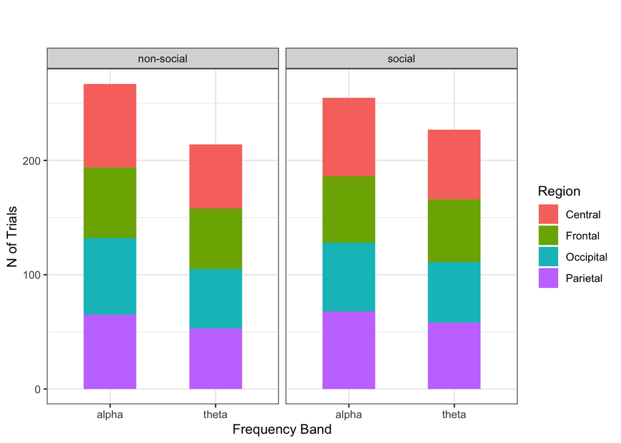

```r
eeg_data_m %>%
  filter(!is.nan(per.pk.fr)) %>%
  select(id, f.b, reg, cond) %>%
  group_by(f.b, reg, cond) %>%
  ggplot(aes(f.b)) +
  geom_bar(aes(fill = reg), width = 0.5) +
  facet_grid( ~ cond) +
  theme(axis.text.x = element_text(angle = 65, vjust = 0.6)) +
  labs(
    title = "",
    subtitle = "",
    x = "Frequency Band",
    y = "N of Trials",
    fill = "Region"
  ) +
  theme_bw()
```

# Data Quantity

DVs:

1. N of clean epochs
2. Fit error

Predictors:

- Condition
- Environmental variables:
  - visual attention
  - capping time
- Phenotype:
  - Age
  - Gender
  - FIQ
  - SDQ
  - CARS
  - Household income
  - Condition * Age

## DV = N of clean epochs

```r
m_nce <-
  lmer(
    data = filter(ds, f.b == "theta" & reg == "Frontal"),
    n.clean.ep ~ cond * Age_yrs + et_looking_prop + time_capping_m +
      Gender + FIQ_ELC + SDQ_tot + CARS_Total_Raw + scale(household_income) +
      (1 | id)
  )
summ_nce <- m_nce %>%
  broom.mixed::tidy() %>%
  mutate_if(is.numeric, function(x)
    round(x, 4)) %>%
  flextable::flextable()
summ_nce
```

| effect | group | term | estimate | std.error | statistic | df | p.value |
| --- | --- | --- | --- | --- | --- | --- | --- |
| fixed |  | (Intercept) | 50.2832 | 50.7083 | 0.9916 | 30.4251 | 0.3292 |
| fixed |  | condsocial | -0.9711 | 13.5491 | -0.0717 | 36.6249 | 0.9433 |
| fixed |  | Age_yrs | -2.5112 | 1.4872 | -1.6886 | 47.3217 | 0.0979 |
| fixed |  | et_looking_prop | 90.6650 | 18.9563 | 4.7829 | 58.6681 | 0.0000 |
| fixed |  | time_capping_m | -0.8998 | 0.4520 | -1.9906 | 29.4809 | 0.0559 |
| fixed |  | GenderMale | -0.1651 | 5.2023 | -0.0317 | 28.7050 | 0.9749 |
| fixed |  | FIQ_ELC | 0.1503 | 0.1768 | 0.8502 | 28.5140 | 0.4023 |
| fixed |  | SDQ_tot | 0.6141 | 0.4193 | 1.4644 | 28.7837 | 0.1539 |
| fixed |  | CARS_Total_Raw | -2.0364 | 2.1411 | -0.9511 | 28.9939 | 0.3494 |
| fixed |  | scale(household_income) | 2.2576 | 2.6225 | 0.8609 | 28.5031 | 0.3965 |
| fixed |  | condsocial:Age_yrs | 1.1306 | 1.5424 | 0.7330 | 36.1028 | 0.4683 |
| ran_pars | id | sd__(Intercept) | 7.7942 |  |  |  |  |
| ran_pars | Residual | sd__Observation | 14.2312 |  |  |  |  |

The number of clean epochs is significantly influenced by the Eye-Tracking Looking Proportion (positive).

## DV = Foof fit error

This measure is identical across frequency bands and regions (alpha and Frontal have been selected, but theta will retain same result).

```r
m_rsq <-
  lmer(
    data = filter(eeg_data_m, f.b == "alpha" & reg == "Frontal"),
    foof.rsq ~ cond * Age_yrs + et_looking_prop + time_capping_m +
      Gender + FIQ_ELC + SDQ_tot + CARS_Total_Raw + scale(household_income) +
      (1 | id)
  )
summ_rsq <- m_rsq %>%
  broom.mixed::tidy() %>%
  mutate_if(is.numeric, function(x)
    round(x, 4)) %>%
  flextable::flextable()
summ_rsq
```

| effect | group | term | estimate | std.error | statistic | df | p.value |
| --- | --- | --- | --- | --- | --- | --- | --- |
| fixed |  | (Intercept) | 1.0032 | 0.0163 | 61.5141 | 29.7631 | 0.0000 |
| fixed |  | condsocial | -0.0028 | 0.0025 | -1.1161 | 35.8810 | 0.2718 |
| fixed |  | Age_yrs | -0.0013 | 0.0004 | -2.8586 | 35.2089 | 0.0071 |
| fixed |  | et_looking_prop | 0.0000 | 0.0045 | 0.0048 | 58.1617 | 0.9962 |
| fixed |  | time_capping_m | -0.0001 | 0.0001 | -0.4190 | 29.4882 | 0.6782 |
| fixed |  | GenderMale | 0.0000 | 0.0017 | -0.0196 | 28.7806 | 0.9845 |
| fixed |  | FIQ_ELC | 0.0000 | 0.0001 | 0.0500 | 28.6093 | 0.9605 |
| fixed |  | SDQ_tot | 0.0001 | 0.0001 | 0.9177 | 28.8515 | 0.3664 |
| fixed |  | CARS_Total_Raw | -0.0001 | 0.0007 | -0.0967 | 29.0417 | 0.9236 |
| fixed |  | scale(household_income) | 0.0004 | 0.0009 | 0.4707 | 28.5996 | 0.6414 |
| fixed |  | condsocial:Age_yrs | 0.0004 | 0.0003 | 1.3553 | 35.4477 | 0.1839 |
| ran_pars | id | sd__(Intercept) | 0.0037 |  |  |  |  |
| ran_pars | Residual | sd__Observation | 0.0026 |  |  |  |  |

The foof fit error is significantly influenced by Age (negative).

# Condition Estimates

DVs:

Predictors:

- Number of clean epochs
- Age
- Gender
- FIQ
- SDQ
- CARS
- Household income
- Condition * Age

Each table includes the type of effect (fixed, random), grouping (just for random effects), term (meaning the predictor), estimate (meaning the coefficient, a measure of the unstandardized effect size for that predictor), standard error, statistic (meaning the T-value or distance form 0) and p-value. A brief paragraph summarizes which predictors are significantly associated with the DV, and the direction of the association in parenthesis (positive/negative, e.g., a positive association means that for higher values of the predictor, the DV also takes higher values, while a negative association means that for higher values of the predictor, the DV takes lower values).

## DV = Canonical Power Theta

```r
m_powT <-
  lmer(
    data = filter(eeg_data_m, n.clean.ep > 20 & f.b == "theta"),
    can.pow ~ n.clean.ep + cond * Age_yrs + Gender + FIQ_ELC +
      SDQ_tot + CARS_Total_Raw + scale(household_income) +
      (1 + reg | id)
  )
summary(m_powT)
```

```
## Linear mixed model fit by REML. t-tests use Satterthwaite's method [
## lmerModLmerTest]
## Formula: can.pow ~ n.clean.ep + cond * Age_yrs + Gender + FIQ_ELC + SDQ_tot +
##     CARS_Total_Raw + scale(household_income) + (1 + reg | id)
##    Data: filter(eeg_data_m, n.clean.ep > 20 & f.b == "theta")
##
## REML criterion at convergence: -24.8
##
## Scaled residuals:
##     Min      1Q  Median      3Q     Max
## -3.8281 -0.4882  0.0003  0.4384  4.1526
##
## Random effects:
##  Groups   Name         Variance Std.Dev. Corr
##  id       (Intercept)  0.30336  0.5508
##           regFrontal   0.15895  0.3987   -0.70
##           regOccipital 0.08966  0.2994   -0.70  0.88
##           regParietal  0.03883  0.1970   -0.02  0.33  0.22
##  Residual              0.01498  0.1224
## Number of obs: 416, groups:  id, 52
##
## Fixed effects:
##                           Estimate Std. Error         df t value Pr(>|t|)
## (Intercept)              2.100e+00  1.300e+00  4.508e+01   1.616  0.11308
## n.clean.ep              -1.567e-03  5.742e-04  2.157e+02  -2.729  0.00688 **
## condsocial               2.438e-01  4.630e-02  2.053e+02   5.265 3.52e-07 ***
## Age_yrs                 -8.791e-02  3.167e-02  4.559e+01  -2.776  0.00796 **
## GenderMale               9.001e-02  1.096e-01  4.495e+01   0.821  0.41587
## FIQ_ELC                  2.403e-03  4.818e-03  4.489e+01   0.499  0.62042
## SDQ_tot                  4.012e-03  1.108e-02  4.500e+01   0.362  0.71885
## CARS_Total_Raw          -2.963e-02  5.803e-02  4.490e+01  -0.511  0.61217
## scale(household_income) -2.605e-02  6.286e-02  4.492e+01  -0.414  0.68060
## condsocial:Age_yrs      -1.631e-02  5.510e-03  2.056e+02  -2.961  0.00343 **
## ---
## Signif. codes:  0 '***' 0.001 '**' 0.01 '*' 0.05 '.' 0.1 ' ' 1
##
## Correlation of Fixed Effects:
##             (Intr) n.cln. cndscl Ag_yrs GndrMl FIQ_EL SDQ_tt CARS_T scl(_)
## n.clean.ep  -0.043
## condsocial  -0.024  0.166
## Age_yrs     -0.633  0.024  0.084
## GenderMale  -0.151 -0.026 -0.004  0.099
## FIQ_ELC     -0.753 -0.003  0.000  0.573  0.024
## SDQ_tot      0.048 -0.034 -0.006  0.080 -0.177  0.041
## CARS_Ttl_Rw -0.894  0.011  0.002  0.336  0.137  0.455 -0.263
## scl(hshld_)  0.030 -0.019 -0.003  0.248  0.141 -0.164  0.201 -0.085
## cndscl:Ag_y  0.027 -0.248 -0.963 -0.088  0.006  0.001  0.009 -0.003  0.005
```

```r
summ_powT <- m_powT %>%
  broom.mixed::tidy() %>%
  mutate_if(is.numeric, function(x)
    round(x, 4)) %>%
  flextable::flextable()
summ_powT
```

| effect | group | term | estimate | std.error | statistic | df | p.value |
| --- | --- | --- | --- | --- | --- | --- | --- |
| fixed |  | (Intercept) | 2.1003 | 1.2997 | 1.6160 | 45.0784 | 0.1131 |
| fixed |  | n.clean.ep | -0.0016 | 0.0006 | -2.7289 | 215.7242 | 0.0069 |
| fixed |  | condsocial | 0.2438 | 0.0463 | 5.2654 | 205.2604 | 0.0000 |
| fixed |  | Age_yrs | -0.0879 | 0.0317 | -2.7758 | 45.5857 | 0.0080 |
| fixed |  | GenderMale | 0.0900 | 0.1096 | 0.8212 | 44.9485 | 0.4159 |
| fixed |  | FIQ_ELC | 0.0024 | 0.0048 | 0.4987 | 44.8919 | 0.6204 |
| fixed |  | SDQ_tot | 0.0040 | 0.0111 | 0.3623 | 44.9951 | 0.7189 |
| fixed |  | CARS_Total_Raw | -0.0296 | 0.0580 | -0.5105 | 44.9023 | 0.6122 |
| fixed |  | scale(household_income) | -0.0260 | 0.0629 | -0.4143 | 44.9210 | 0.6806 |
| fixed |  | condsocial:Age_yrs | -0.0163 | 0.0055 | -2.9609 | 205.6337 | 0.0034 |
| ran_pars | id | sd__(Intercept) | 0.5508 |  |  |  |  |
| ran_pars | id | cor__(Intercept).regFrontal | -0.7044 |  |  |  |  |
| ran_pars | id | cor__(Intercept).regOccipital | -0.6975 |  |  |  |  |
| ran_pars | id | cor__(Intercept).regParietal | -0.0222 |  |  |  |  |
| ran_pars | id | sd__regFrontal | 0.3987 |  |  |  |  |
| ran_pars | id | cor__regFrontal.regOccipital | 0.8797 |  |  |  |  |
| ran_pars | id | cor__regFrontal.regParietal | 0.3323 |  |  |  |  |
| ran_pars | id | sd__regOccipital | 0.2994 |  |  |  |  |
| ran_pars | id | cor__regOccipital.regParietal | 0.2160 |  |  |  |  |
| ran_pars | id | sd__regParietal | 0.1970 |  |  |  |  |
| ran_pars | Residual | sd__Observation | 0.1224 |  |  |  |  |

The Canonical Theta Power is significantly influenced by the N of Clen Epochs (negative), Condition (in the social condition: positive), Age (negative), and the interaction of condition by age (negative).

## DV = Canonical Power Alpha

```r
m_powA <-
  lmer(
    data = filter(eeg_data_m, n.clean.ep > 20 & f.b == "alpha"),
    can.pow ~ n.clean.ep + cond * Age_yrs + Gender + FIQ_ELC +
      SDQ_tot + CARS_Total_Raw + scale(household_income) +
      (1 + reg | id)
  )
summ_powA <- m_powA %>%
  broom.mixed::tidy() %>%
  mutate_if(is.numeric, function(x)
    round(x, 4)) %>%
  flextable::flextable()
summ_powA
```

| effect | group | term | estimate | std.error | statistic | df | p.value |
| --- | --- | --- | --- | --- | --- | --- | --- |
| fixed |  | (Intercept) | 0.9779 | 1.3543 | 0.7220 | 45.1340 | 0.4740 |
| fixed |  | n.clean.ep | 0.0003 | 0.0005 | 0.4949 | 212.9785 | 0.6212 |
| fixed |  | condsocial | -0.0226 | 0.0412 | -0.5484 | 205.2628 | 0.5840 |
| fixed |  | Age_yrs | -0.0689 | 0.0330 | -2.0891 | 45.5028 | 0.0423 |
| fixed |  | GenderMale | 0.0935 | 0.1142 | 0.8189 | 45.0395 | 0.4172 |
| fixed |  | FIQ_ELC | 0.0040 | 0.0050 | 0.8033 | 44.9970 | 0.4260 |
| fixed |  | SDQ_tot | 0.0063 | 0.0115 | 0.5438 | 45.0740 | 0.5892 |
| fixed |  | CARS_Total_Raw | -0.0497 | 0.0605 | -0.8211 | 45.0044 | 0.4159 |
| fixed |  | scale(household_income) | -0.0881 | 0.0655 | -1.3440 | 45.0192 | 0.1857 |
| fixed |  | condsocial:Age_yrs | 0.0017 | 0.0049 | 0.3559 | 205.5378 | 0.7223 |
| ran_pars | id | sd__(Intercept) | 0.5503 |  |  |  |  |
| ran_pars | id | cor__(Intercept).regFrontal | -0.7024 |  |  |  |  |
| ran_pars | id | cor__(Intercept).regOccipital | -0.6127 |  |  |  |  |
| ran_pars | id | cor__(Intercept).regParietal | -0.3428 |  |  |  |  |
| ran_pars | id | sd__regFrontal | 0.2766 |  |  |  |  |
| ran_pars | id | cor__regFrontal.regOccipital | 0.7310 |  |  |  |  |
| ran_pars | id | cor__regFrontal.regParietal | 0.5883 |  |  |  |  |
| ran_pars | id | sd__regOccipital | 0.3044 |  |  |  |  |
| ran_pars | id | cor__regOccipital.regParietal | 0.5118 |  |  |  |  |
| ran_pars | id | sd__regParietal | 0.3794 |  |  |  |  |
| ran_pars | Residual | sd__Observation | 0.1088 |  |  |  |  |

The Canonical Alpha Power is significantly influenced by Age (negative).

## DV = 1/f intercept

```r
m_1fint <-
  lmer(
    data = filter(eeg_data_m, n.clean.ep > 20 & foof.rsq > 0.95 &
                    f.b == "theta"),
    foof.int ~ n.clean.ep + cond * Age_yrs + Gender + FIQ_ELC +
      SDQ_tot + CARS_Total_Raw + scale(household_income) +
      (1 + reg | id)
  )
summ_1fint <- m_1fint %>%
  broom.mixed::tidy() %>%
  mutate_if(is.numeric, function(x)
    round(x, 4)) %>%
  flextable::flextable()
summ_1fint
```

| effect | group | term | estimate | std.error | statistic | df | p.value |
| --- | --- | --- | --- | --- | --- | --- | --- |
| fixed |  | (Intercept) | 1.9864 | 0.4153 | 4.7831 | 45.4722 | 0.0000 |
| fixed |  | n.clean.ep | -0.0014 | 0.0004 | -3.9009 | 240.9055 | 0.0001 |
| fixed |  | condsocial | -0.0232 | 0.0304 | -0.7632 | 206.0830 | 0.4462 |
| fixed |  | Age_yrs | -0.0321 | 0.0102 | -3.1390 | 47.7161 | 0.0029 |
| fixed |  | GenderMale | 0.0421 | 0.0349 | 1.2041 | 44.9854 | 0.2349 |
| fixed |  | FIQ_ELC | 0.0013 | 0.0015 | 0.8644 | 44.7835 | 0.3920 |
| fixed |  | SDQ_tot | 0.0018 | 0.0035 | 0.5117 | 45.1527 | 0.6113 |
| fixed |  | CARS_Total_Raw | -0.0150 | 0.0185 | -0.8113 | 44.8222 | 0.4215 |
| fixed |  | scale(household_income) | -0.0014 | 0.0200 | -0.0680 | 44.8871 | 0.9461 |
| fixed |  | condsocial:Age_yrs | 0.0012 | 0.0036 | 0.3355 | 207.4269 | 0.7376 |
| ran_pars | id | sd__(Intercept) | 0.2755 |  |  |  |  |
| ran_pars | id | cor__(Intercept).regFrontal | -0.9039 |  |  |  |  |
| ran_pars | id | cor__(Intercept).regOccipital | -0.7869 |  |  |  |  |
| ran_pars | id | cor__(Intercept).regParietal | -0.8255 |  |  |  |  |
| ran_pars | id | sd__regFrontal | 0.1703 |  |  |  |  |
| ran_pars | id | cor__regFrontal.regOccipital | 0.7449 |  |  |  |  |
| ran_pars | id | cor__regFrontal.regParietal | 0.7424 |  |  |  |  |
| ran_pars | id | sd__regOccipital | 0.2586 |  |  |  |  |
| ran_pars | id | cor__regOccipital.regParietal | 0.7996 |  |  |  |  |
| ran_pars | id | sd__regParietal | 0.1279 |  |  |  |  |
| ran_pars | Residual | sd__Observation | 0.0803 |  |  |  |  |

The 1/f Intercept is significantly influenced by the N of Clean Epochs (negative) and Age (negative).

## DV = 1/f slope

This measure is identical across frequency bands (alpha has been selected, but theta will retain same result).

```r
m_1fsl <-
  lmer(
    data = filter(eeg_data_m, n.clean.ep > 20 & foof.rsq > 0.95 &
                    f.b == "alpha"),
    foof.sl ~ n.clean.ep + cond * Age_yrs + Gender + FIQ_ELC +
      SDQ_tot + CARS_Total_Raw + scale(household_income) +
      (1 + reg | id)
  )
summ_1fsl <- m_1fsl %>%
  broom.mixed::tidy() %>%
  mutate_if(is.numeric, function(x)
    round(x, 4)) %>%
  flextable::flextable()
summ_1fsl
```

| effect | group | term | estimate | std.error | statistic | df | p.value |
| --- | --- | --- | --- | --- | --- | --- | --- |
| fixed |  | (Intercept) | 1.4985 | 0.3120 | 4.8025 | 45.6410 | 0.0000 |
| fixed |  | n.clean.ep | -0.0009 | 0.0003 | -3.2288 | 241.8329 | 0.0014 |
| fixed |  | condsocial | -0.0240 | 0.0233 | -1.0304 | 206.2736 | 0.3040 |
| fixed |  | Age_yrs | -0.0112 | 0.0077 | -1.4651 | 47.9910 | 0.1494 |
| fixed |  | GenderMale | 0.0492 | 0.0263 | 1.8746 | 45.1399 | 0.0673 |
| fixed |  | FIQ_ELC | 0.0021 | 0.0012 | 1.8503 | 44.9295 | 0.0709 |
| fixed |  | SDQ_tot | 0.0008 | 0.0027 | 0.3059 | 45.3132 | 0.7611 |
| fixed |  | CARS_Total_Raw | 0.0179 | 0.0139 | 1.2858 | 44.9677 | 0.2051 |
| fixed |  | scale(household_income) | -0.0011 | 0.0151 | -0.0736 | 45.0382 | 0.9417 |
| fixed |  | condsocial:Age_yrs | 0.0007 | 0.0028 | 0.2434 | 207.6574 | 0.8079 |
| ran_pars | id | sd__(Intercept) | 0.1701 |  |  |  |  |
| ran_pars | id | cor__(Intercept).regFrontal | -0.0736 |  |  |  |  |
| ran_pars | id | cor__(Intercept).regOccipital | -0.4130 |  |  |  |  |
| ran_pars | id | cor__(Intercept).regParietal | -0.8430 |  |  |  |  |
| ran_pars | id | sd__regFrontal | 0.1214 |  |  |  |  |
| ran_pars | id | cor__regFrontal.regOccipital | -0.1964 |  |  |  |  |
| ran_pars | id | cor__regFrontal.regParietal | -0.3007 |  |  |  |  |
| ran_pars | id | sd__regOccipital | 0.1352 |  |  |  |  |
| ran_pars | id | cor__regOccipital.regParietal | 0.6302 |  |  |  |  |
| ran_pars | id | sd__regParietal | 0.1307 |  |  |  |  |
| ran_pars | Residual | sd__Observation | 0.0616 |  |  |  |  |

The 1/f Slope is significantly influenced by the N of Clean Epochs (negative).

## DV = Frequency of periodic peak in theta range

```r
m_ppfT <-
  lmer(
    data = filter(eeg_data_m, n.clean.ep > 20 & foof.rsq > 0.95 &
                    f.b == "theta"),
    per.pk.fr ~ n.clean.ep + cond * Age_yrs + Gender + FIQ_ELC +
      SDQ_tot + CARS_Total_Raw + scale(household_income) +
      (1 + reg | id)
  )
summ_ppfT <- m_ppfT %>%
  broom.mixed::tidy() %>%
  mutate_if(is.numeric, function(x)
    round(x, 4)) %>%
  flextable::flextable()
summ_ppfT
```

| effect | group | term | estimate | std.error | statistic | df | p.value |
| --- | --- | --- | --- | --- | --- | --- | --- |
| fixed |  | (Intercept) | 9.8718 | 1.7029 | 5.7971 | 45.5529 | 0.0000 |
| fixed |  | n.clean.ep | 0.0030 | 0.0030 | 1.0012 | 145.6437 | 0.3184 |
| fixed |  | condsocial | 0.8199 | 0.3218 | 2.5476 | 173.8090 | 0.0117 |
| fixed |  | Age_yrs | 0.0443 | 0.0447 | 0.9909 | 56.2122 | 0.3260 |
| fixed |  | GenderMale | 0.0150 | 0.1388 | 0.1081 | 38.6144 | 0.9145 |
| fixed |  | FIQ_ELC | -0.0177 | 0.0061 | -2.8905 | 40.3274 | 0.0062 |
| fixed |  | SDQ_tot | -0.0106 | 0.0144 | -0.7328 | 42.8757 | 0.4677 |
| fixed |  | CARS_Total_Raw | -0.1957 | 0.0759 | -2.5774 | 44.9272 | 0.0133 |
| fixed |  | scale(household_income) | 0.1546 | 0.0816 | 1.8939 | 41.9472 | 0.0652 |
| fixed |  | condsocial:Age_yrs | -0.1117 | 0.0387 | -2.8834 | 174.9621 | 0.0044 |
| ran_pars | id | sd__(Intercept) | 0.5758 |  |  |  |  |
| ran_pars | id | cor__(Intercept).regFrontal | -0.8570 |  |  |  |  |
| ran_pars | id | cor__(Intercept).regOccipital | 0.0274 |  |  |  |  |
| ran_pars | id | cor__(Intercept).regParietal | -0.0044 |  |  |  |  |
| ran_pars | id | sd__regFrontal | 0.6494 |  |  |  |  |
| ran_pars | id | cor__regFrontal.regOccipital | 0.3128 |  |  |  |  |
| ran_pars | id | cor__regFrontal.regParietal | -0.4474 |  |  |  |  |
| ran_pars | id | sd__regOccipital | 0.3285 |  |  |  |  |
| ran_pars | id | cor__regOccipital.regParietal | -0.9375 |  |  |  |  |
| ran_pars | id | sd__regParietal | 0.3741 |  |  |  |  |
| ran_pars | Residual | sd__Observation | 0.6998 |  |  |  |  |

The frequency of periodic peak in theta range is significantly influenced by condition (in social condition: positive), FIQ (negative), CARS (negative), and the interaction of condition by age (negative).

## DV = Amplitude of periodic peak in theta range

```r
m_ppaT <-
  lmer(
    data = filter(eeg_data_m, n.clean.ep > 20 & foof.rsq > 0.95 &
                    f.b == "theta"),
    per.pk.amp ~ n.clean.ep + cond * Age_yrs + Gender + FIQ_ELC +
      SDQ_tot + CARS_Total_Raw + scale(household_income) +
      (1 + reg | id)
  )
summ_ppaT <- m_ppaT %>%
  broom.mixed::tidy() %>%
  mutate_if(is.numeric, function(x)
    round(x, 4)) %>%
  flextable::flextable()
summ_ppaT
```

| effect | group | term | estimate | std.error | statistic | df | p.value |
| --- | --- | --- | --- | --- | --- | --- | --- |
| fixed |  | (Intercept) | 1.4538 | 0.5932 | 2.4506 | 52.3437 | 0.0176 |
| fixed |  | n.clean.ep | 0.0002 | 0.0005 | 0.3264 | 156.2403 | 0.7445 |
| fixed |  | condsocial | 0.2091 | 0.0436 | 4.7986 | 125.5739 | 0.0000 |
| fixed |  | Age_yrs | -0.0284 | 0.0142 | -2.0020 | 49.0583 | 0.0508 |
| fixed |  | GenderMale | -0.0319 | 0.0459 | -0.6937 | 42.8076 | 0.4916 |
| fixed |  | FIQ_ELC | -0.0017 | 0.0021 | -0.8286 | 45.7982 | 0.4116 |
| fixed |  | SDQ_tot | -0.0075 | 0.0045 | -1.6689 | 40.5656 | 0.1028 |
| fixed |  | CARS_Total_Raw | -0.0430 | 0.0262 | -1.6409 | 51.3472 | 0.1069 |
| fixed |  | scale(household_income) | -0.0336 | 0.0252 | -1.3320 | 39.1451 | 0.1906 |
| fixed |  | condsocial:Age_yrs | -0.0193 | 0.0053 | -3.6558 | 125.7199 | 0.0004 |
| ran_pars | id | sd__(Intercept) | 0.2043 |  |  |  |  |
| ran_pars | id | cor__(Intercept).regFrontal | -0.2242 |  |  |  |  |
| ran_pars | id | cor__(Intercept).regOccipital | -0.7142 |  |  |  |  |
| ran_pars | id | cor__(Intercept).regParietal | 0.0620 |  |  |  |  |
| ran_pars | id | sd__regFrontal | 0.1975 |  |  |  |  |
| ran_pars | id | cor__regFrontal.regOccipital | 0.7499 |  |  |  |  |
| ran_pars | id | cor__regFrontal.regParietal | 0.0868 |  |  |  |  |
| ran_pars | id | sd__regOccipital | 0.1650 |  |  |  |  |
| ran_pars | id | cor__regOccipital.regParietal | 0.0456 |  |  |  |  |
| ran_pars | id | sd__regParietal | 0.1915 |  |  |  |  |
| ran_pars | Residual | sd__Observation | 0.0915 |  |  |  |  |

The amplitude of periodic peak in theta range is significantly influenced by condition (in social condition: positive) and the interaction of condition by age (negative).

## DV = Frequency of periodic peak in alpha range

```r
m_ppfA <-
  lmer(
    data = filter(eeg_data_m, n.clean.ep > 20 & foof.rsq > 0.95 &
                    f.b == "alpha"),
    per.pk.fr ~ n.clean.ep + cond * Age_yrs + Gender + FIQ_ELC +
      SDQ_tot + CARS_Total_Raw + scale(household_income) +
      (1 + reg | id)
  )
```

```
## boundary (singular) fit: see help('isSingular')
```

```r
summ_ppfA <- m_ppfA %>%
  broom.mixed::tidy() %>%
  mutate_if(is.numeric, function(x)
    round(x, 4)) %>%
  flextable::flextable()
summ_ppfA
```

| effect | group | term | estimate | std.error | statistic | df | p.value |
| --- | --- | --- | --- | --- | --- | --- | --- |
| fixed |  | (Intercept) | 8.6729 | 1.8994 | 4.5662 | 51.1658 | 0.0000 |
| fixed |  | n.clean.ep | -0.0004 | 0.0022 | -0.1866 | 242.8115 | 0.8521 |
| fixed |  | condsocial | 0.5663 | 0.1956 | 2.8951 | 205.9745 | 0.0042 |
| fixed |  | Age_yrs | 0.1103 | 0.0460 | 2.3976 | 52.1258 | 0.0201 |
| fixed |  | GenderMale | -0.1037 | 0.1529 | -0.6786 | 44.6255 | 0.5009 |
| fixed |  | FIQ_ELC | -0.0015 | 0.0067 | -0.2179 | 43.8651 | 0.8285 |
| fixed |  | SDQ_tot | 0.0303 | 0.0155 | 1.9535 | 45.5678 | 0.0569 |
| fixed |  | CARS_Total_Raw | -0.0059 | 0.0862 | -0.0687 | 52.9172 | 0.9455 |
| fixed |  | scale(household_income) | 0.0823 | 0.0874 | 0.9413 | 44.1967 | 0.3517 |
| fixed |  | condsocial:Age_yrs | -0.0542 | 0.0234 | -2.3193 | 208.2923 | 0.0213 |
| ran_pars | id | sd__(Intercept) | 0.4778 |  |  |  |  |
| ran_pars | id | cor__(Intercept).regFrontal | 0.2396 |  |  |  |  |
| ran_pars | id | cor__(Intercept).regOccipital | -0.0471 |  |  |  |  |
| ran_pars | id | cor__(Intercept).regParietal | -0.3125 |  |  |  |  |
| ran_pars | id | sd__regFrontal | 0.2034 |  |  |  |  |
| ran_pars | id | cor__regFrontal.regOccipital | 0.8635 |  |  |  |  |
| ran_pars | id | cor__regFrontal.regParietal | 0.7167 |  |  |  |  |
| ran_pars | id | sd__regOccipital | 0.5875 |  |  |  |  |
| ran_pars | id | cor__regOccipital.regParietal | 0.5393 |  |  |  |  |
| ran_pars | id | sd__regParietal | 0.2385 |  |  |  |  |
| ran_pars | Residual | sd__Observation | 0.4925 |  |  |  |  |

The frequency of periodic peak in alpha range is significantly influenced by condition (positive), Age (positive) and the interaction of condition by age (negative).

```r
m_ppaA <-
  lmer(
    data = filter(eeg_data_m, n.clean.ep > 20 & foof.rsq > 0.95 &
                    f.b == "alpha"),
    per.pk.amp ~ n.clean.ep + cond * Age_yrs + Gender + FIQ_ELC +
      SDQ_tot + CARS_Total_Raw + scale(household_income) +
      (1 + reg | id)
  )
summ_ppaA <- m_ppaA %>%
  broom.mixed::tidy() %>%
  mutate_if(is.numeric, function(x)
    round(x, 4)) %>%
  flextable::flextable()
summ_ppaA
```

| effect | group | term | estimate | std.error | statistic | df | p.value |
| --- | --- | --- | --- | --- | --- | --- | --- |
| fixed |  | (Intercept) | 0.4409 | 0.6206 | 0.7104 | 44.4630 | 0.4812 |
| fixed |  | n.clean.ep | 0.0006 | 0.0005 | 1.2224 | 202.3867 | 0.2230 |
| fixed |  | condsocial | -0.0244 | 0.0422 | -0.5797 | 170.0217 | 0.5629 |
| fixed |  | Age_yrs | -0.0295 | 0.0139 | -2.1151 | 45.8369 | 0.0399 |
| fixed |  | GenderMale | -0.0308 | 0.0461 | -0.6688 | 42.1674 | 0.5072 |
| fixed |  | FIQ_ELC | 0.0011 | 0.0020 | 0.5344 | 40.8313 | 0.5960 |
| fixed |  | SDQ_tot | -0.0040 | 0.0046 | -0.8677 | 43.6810 | 0.3903 |
| fixed |  | CARS_Total_Raw | 0.0059 | 0.0293 | 0.2010 | 46.8080 | 0.8415 |
| fixed |  | scale(household_income) | -0.0700 | 0.0266 | -2.6313 | 42.2596 | 0.0118 |
| fixed |  | condsocial:Age_yrs | -0.0007 | 0.0050 | -0.1358 | 170.7066 | 0.8921 |
| ran_pars | id | sd__(Intercept) | 0.6676 |  |  |  |  |
| ran_pars | id | cor__(Intercept).regFrontal | -0.9683 |  |  |  |  |
| ran_pars | id | cor__(Intercept).regOccipital | -0.9728 |  |  |  |  |
| ran_pars | id | cor__(Intercept).regParietal | -0.9129 |  |  |  |  |
| ran_pars | id | sd__regFrontal | 0.4615 |  |  |  |  |
| ran_pars | id | cor__regFrontal.regOccipital | 0.9717 |  |  |  |  |
| ran_pars | id | cor__regFrontal.regParietal | 0.9454 |  |  |  |  |
| ran_pars | id | sd__regOccipital | 0.5562 |  |  |  |  |
| ran_pars | id | cor__regOccipital.regParietal | 0.9692 |  |  |  |  |
| ran_pars | id | sd__regParietal | 0.3626 |  |  |  |  |
| ran_pars | Residual | sd__Observation | 0.1058 |  |  |  |  |

The amplitude of periodic peak in alpha range is significantly influenced by Age (negative) and household income (negative).

## DV = Periodic power theta

```r
m_ppT <-
  lmer(
    data = filter(eeg_data_m, n.clean.ep > 20 & foof.rsq > 0.95 &
                    f.b == "theta"),
    per.pow ~ n.clean.ep + cond * Age_yrs + Gender + FIQ_ELC +
      SDQ_tot + CARS_Total_Raw + scale(household_income) +
      (1 + reg | id)
  )
summ_ppT <- m_ppT %>%
  broom.mixed::tidy() %>%
  mutate_if(is.numeric, function(x)
    round(x, 4)) %>%
  flextable::flextable()
summ_ppT
```

| effect | group | term | estimate | std.error | statistic | df | p.value |
| --- | --- | --- | --- | --- | --- | --- | --- |
| fixed |  | (Intercept) | 0.5627 | 0.3661 | 1.5373 | 45.3175 | 0.1312 |
| fixed |  | n.clean.ep | 0.0002 | 0.0003 | 0.6361 | 230.7881 | 0.5254 |
| fixed |  | condsocial | 0.1130 | 0.0213 | 5.3057 | 205.7386 | 0.0000 |
| fixed |  | Age_yrs | -0.0223 | 0.0090 | -2.4905 | 46.7103 | 0.0164 |
| fixed |  | GenderMale | -0.0146 | 0.0308 | -0.4722 | 44.9935 | 0.6391 |
| fixed |  | FIQ_ELC | 0.0008 | 0.0014 | 0.6129 | 44.8542 | 0.5430 |
| fixed |  | SDQ_tot | -0.0013 | 0.0031 | -0.4191 | 45.1080 | 0.6771 |
| fixed |  | CARS_Total_Raw | -0.0134 | 0.0163 | -0.8232 | 44.8794 | 0.4147 |
| fixed |  | scale(household_income) | -0.0353 | 0.0177 | -1.9961 | 44.9263 | 0.0520 |
| fixed |  | condsocial:Age_yrs | -0.0082 | 0.0025 | -3.2404 | 206.6555 | 0.0014 |
| ran_pars | id | sd__(Intercept) | 0.1398 |  |  |  |  |
| ran_pars | id | cor__(Intercept).regFrontal | -0.3424 |  |  |  |  |
| ran_pars | id | cor__(Intercept).regOccipital | -0.6830 |  |  |  |  |
| ran_pars | id | cor__(Intercept).regParietal | -0.0659 |  |  |  |  |
| ran_pars | id | sd__regFrontal | 0.0623 |  |  |  |  |
| ran_pars | id | cor__regFrontal.regOccipital | 0.5835 |  |  |  |  |
| ran_pars | id | cor__regFrontal.regParietal | 0.0652 |  |  |  |  |
| ran_pars | id | sd__regOccipital | 0.1271 |  |  |  |  |
| ran_pars | id | cor__regOccipital.regParietal | 0.3748 |  |  |  |  |
| ran_pars | id | sd__regParietal | 0.0705 |  |  |  |  |
| ran_pars | Residual | sd__Observation | 0.0563 |  |  |  |  |

The periodic power in theta range is significantly influenced by condition (in social: positive), age (negative) and the interaction of condition by age (negative).

## DV = Periodic power alpha

```r
m_ppA <-
  lmer(data = filter(eeg_data_m, n.clean.ep > 20 & foof.rsq > 0.95 & f.b == "alpha"),
    per.pow ~ n.clean.ep + cond * Age_yrs + Gender + FIQ_ELC +
      SDQ_tot + CARS_Total_Raw + scale(household_income) +
      (1 + reg | id)
  )
summ_ppA <- m_ppA %>%
  broom.mixed::tidy() %>%
  mutate_if(is.numeric, function(x) round(x, 4)) %>%
  flextable::flextable()
summ_ppA
```

| effect | group | term | estimate | std.error | statistic | df | p.value |
| --- | --- | --- | --- | --- | --- | --- | --- |
| fixed |  | (Intercept) | 0.5928 | 0.4247 | 1.3958 | 45.2934 | 0.1696 |
| fixed |  | n.clean.ep | 0.0007 | 0.0002 | 3.0658 | 221.8274 | 0.0024 |
| fixed |  | condsocial | -0.0116 | 0.0192 | -0.6048 | 205.5601 | 0.5460 |
| fixed |  | Age_yrs | -0.0170 | 0.0104 | -1.6421 | 46.1245 | 0.1074 |
| fixed |  | GenderMale | -0.0049 | 0.0358 | -0.1372 | 45.0888 | 0.8915 |
| fixed |  | FIQ_ELC | 0.0015 | 0.0016 | 0.9397 | 44.9996 | 0.3524 |
| fixed |  | SDQ_tot | -0.0009 | 0.0036 | -0.2584 | 45.1621 | 0.7972 |
| fixed |  | CARS_Total_Raw | -0.0252 | 0.0190 | -1.3272 | 45.0157 | 0.1911 |
| fixed |  | scale(household_income) | -0.0471 | 0.0205 | -2.2929 | 45.0458 | 0.0266 |
| fixed |  | condsocial:Age_yrs | 0.0002 | 0.0023 | 0.0991 | 206.1439 | 0.9212 |
| ran_pars | id | sd__(Intercept) | 0.3669 |  |  |  |  |
| ran_pars | id | cor__(Intercept).regFrontal | -0.9260 |  |  |  |  |
| ran_pars | id | cor__(Intercept).regOccipital | -0.9316 |  |  |  |  |
| ran_pars | id | cor__(Intercept).regParietal | -0.8652 |  |  |  |  |
| ran_pars | id | sd__regFrontal | 0.2768 |  |  |  |  |
| ran_pars | id | cor__regFrontal.regOccipital | 0.9231 |  |  |  |  |
| ran_pars | id | cor__regFrontal.regParietal | 0.8792 |  |  |  |  |
| ran_pars | id | sd__regOccipital | 0.2653 |  |  |  |  |
| ran_pars | id | cor__regOccipital.regParietal | 0.9153 |  |  |  |  |
| ran_pars | id | sd__regParietal | 0.1632 |  |  |  |  |
| ran_pars | Residual | sd__Observation | 0.0509 |  |  |  |  |

The periodic power in alpha range is significantly influenced by the N of clean epochs (positive) and household income (negative).